# Analysing data from audio recordings

Analysing Ecological Data with Detection Error

Author

Péter Sólymos

Published

April 21, 2026

# Preamble

```r
library(bSims) # simulations
```

```
mefa4 0.3-12     2025-07-12
```

```
deldir 2.0-4      Nickname: "Idol Comparison"
```

```
     The syntax of deldir() has changed since version
     0.0-10.  Read the help!!!.
```

```
bSims 0.3-3      2025-07-12      chup-chup-zeeee
```

```r
library(detect) # multinomial models
```

```
detect 0.5-1     2026-01-04
```

```r
library(mefa4) # count manipulation
set.seed(1234)
par(mar = c(1, 1, 1, 1))
```

# Introduction

Automated recording units (ARU) are increasingly being used for auditory surveys. There are numerous advantages for using ARUs, e.g. recordings can be stored in perpetuity to be transcribed later, ARUs can be programmed to record at select times and dates over long time periods that would be prohibitive using human observers.

When combining human and ARU based counts, it is important that we understand how the two types of counts relate to each other. There are different approaches to make them comparable, especially with respect to the sensitivity (boosting) of the signal from ARUs. Signal strength (sound pressure levels) from ARUs relate to distance, this it can be used to make sure the differences are understood.

- Triangulation methods: using time-synced ARU grids to track vocalization events in space and time, use this to build a relationship between distance and sound pressure levels
- Paired sampling: simultaneous sampling by human observers and ARUs at the same locations
- Distance calibration: measuring distances in the field and recoding the vocalization events, so a model between the field based distance and sound pressure levels can be established
- Playback experiments: broadcasting known signals at known distances and recording them by ARUs to establish the relationship between sound pressure levels and distance

Bird point counts have been traditionally done by human observers. Combining ARU data with traditional point counts thus require an understanding of how the ARU based counts relate to counts made by human observer in the field. The best way to approach this question is by simultaneously sampling by two approaches: (1) human observers doing traditional point count by registering time and distance interval an individual bird was first detected, and (2) record the same session at the same location by an ARU to be identified/transcribed later in laboratory settings.

# Paired sampling

The expected value of the total count (single species) in a 10-minutes time interval using human observer (subscript $H$) based unlimited radius point count may be written as: $E[Y_{H}] = D A_{H} p_{H}$ where $Y_{H}$ is the count, $D$ is population density, $A$ is the area sampled, $p_{H}$ is the probability that an average individual of the species is available for detection. The quantity $p_{H}$ can be estimated based on removal sampling utilizing the multiple time intervals. $A_{H}$ is often unknown, but can be estimated using the effective detection radius: $A_{H}=\pi EDR_{H}^2$. Human observer based EDR is estimated from distance sampling.

The ARU based survey (subscript $R$ for recorder) can distinguish individuals within distinct time intervals, but assigning these individuals is not yet possible using a single ARU. An ARU based count thus can be seen ans an unlimited radius point count where the effective area sampled is unknown. The expected value for an ARU based count for a given species may be written as: $E[Y_{R}] = D A_{R} p_{R}$. $p_{R}$ can be estimated based on removal sampling utilizing the multiple time intervals from the ARU based survey. The unknown sampling are can be written as $A_{R}=\pi EDR_{R}^2$. The problem is that ARU based EDR cannot directly be estimated from the data because of the lack of multiple distance bands or individual based distance information.

The advantage of simultaneous sampling by human observers (H) and ARUs (A) is that population density ($D=D_{H}=D_{R}$) is identical by design. Possible mechanisms for differences in availability of bird individuals for detection ($p_{H}$ vs. $p_{R}$) can include differences in how detections are made in the field vs. in laboratory (e.g. possibility of double checking).

Both $p_{H}$ and $p_{R}$ can be estimated from the data, and the equivalence $p=p_{H}=p_{R}$ can be tested. So for the sake of simplicity, we assume that human observer and ARU based $p$’s are equal. Dividing the expected values of the counts may be written as:

By substituting $EDR_{R}^2 = \Delta^2 EDR_{H}^2$ (and thus $EDR_{R} = \Delta EDR_{H}$) we get:

$$\frac{E[Y_{R}]}{E[Y_{H}]} = \frac{\Delta^2 EDR_{H}^2}{EDR_{H}^2} = \Delta^2$$

This means that dividing the mean counts from ARU and human observed counts would give an estimate of the squared scaling constant ($\Delta^2$) describing the relationship between the estimated $EDR_{H}$ and the unknown $EDR_{R}$.

# Paired data

Human observer surveys:

- 0-50, 50-100, >100 m distance bands,
- 0-3, 3-5, 5-10 minutes time intervals.

ARU surveys:

- unlimited distance,
- 10 minutes survey in 1-minute time intervals.

```r
paired <- detect::paired
paired$DISTANCE[paired$SurveyType == "ARU"] <- "ARU"
with(paired, ftable(SurveyType, Interval, DISTANCE))
```

```
                    DISTANCE >100 m 0-49 m 50-100 m  ARU
SurveyType Interval
ARU        0-3 min                0      0        0 3349
           3-5 min                0      0        0  675
           5-10 min               0      0        0 1296
           UNK                    0      0        0    3
HUM        0-3 min              877   1270     1387    0
           3-5 min              244    252      393    0
           5-10 min             481    429      645    0
           UNK                    7     20       12    0
```

Select a subset of species that we’ll work with:

```r
xt <- as.matrix(Xtab(Count ~ PKEY + SPECIES,
    data = paired[paired$SurveyType == "HUM", ]
))

SPP <- colnames(xt)
#  number of >0 counts
ndis <- colSums(xt > 0)
#  max count
maxd <- apply(xt, 2, max)
nmin <- 15
SPP <- SPP[ndis >= nmin & maxd > 1]
SPP <- SPP[!(SPP %in%
    c(
        "CANG", "COLO", "COGO", "COME", "FRGU", "BCFR", "UNKN", "RESQ",
        "CORA", "AMCR", "WOSP", "WWCR", "PISI", "EVGR", "RUGR", "SACR",
        "NOFL"
    ))]
SPP
```

```
 [1] "ALFL" "AMRE" "AMRO" "BBWA" "BCCH" "BLBW" "BLJA" "BRCR" "CAGO" "CAJA"
[11] "CAWA" "CCSP" "CEDW" "CHSP" "CMWA" "CONW" "COYE" "CSWA" "DEJU" "FOSP"
[21] "GRYE" "HAWO" "HETH" "LEFL" "LISP" "MAWA" "MOWA" "NAWA" "OCWA" "OVEN"
[31] "PAWA" "PHVI" "PIWO" "RBGR" "RBNU" "RCKI" "REVI" "SOSP" "SWTH" "TEWA"
[41] "WISN" "WIWR" "WTSP" "YBSA" "YRWA"
```

# Availability

We estimated availability for human observer and ARU based counts using the time interval information. ARU based intervals were collapsed to the 0-3-5-10 minutes intervals to match the human observer based design.

```r
xtdurH <- Xtab(
    Count ~ PKEY + Interval + SPECIES,
    paired[paired$SurveyType == "HUM", ]
)
xtdurH <- xtdurH[SPP]
xtdurR <- Xtab(
    Count ~ PKEY + Interval + SPECIES,
    paired[paired$SurveyType == "ARU", ]
)
xtdurR <- xtdurR[SPP]

Ddur <- matrix(c(3, 5, 10), nrow(xtdurH[[1]]), 3, byrow = TRUE)
Ddur2 <- rbind(Ddur, Ddur)

xdur <- nonDuplicated(paired, PKEY, TRUE)
xx <- xdur[rownames(xtdurR[[1]]), ]
```

We estimated availability for species with at least 15 detections in both subsets of the data (making sure that the total count for at least some locations exceeded 1). We analyzed the human observer and ARU based data in a single model using survey type as a dummy variable. We tested if the estimate corresponding to survey type differed significantly from 0 using 95% confidence intervals.

```r
mdurR <- list()
mdurH <- list()
mdurHR <- list()
mdurHR1 <- list()
for (spp in SPP) {
    yR <- as.matrix(xtdurR[[spp]])[, c("0-3 min", "3-5 min", "5-10 min")]
    yH <- as.matrix(xtdurH[[spp]])[, c("0-3 min", "3-5 min", "5-10 min")]
    yHR <- rbind(yH, yR)
    mdurR[[spp]] <- cmulti(yR | Ddur ~ 1, type = "rem")
    mdurH[[spp]] <- cmulti(yH | Ddur ~ 1, type = "rem")
    aru01 <- rep(0:1, each = nrow(yH))
    mdurHR[[spp]] <- cmulti(yHR | Ddur2 ~ 1, type = "rem")
    mdurHR1[[spp]] <- cmulti(yHR | Ddur2 ~ aru01, type = "rem")
}
cfR <- sapply(mdurR, coef)
cfH <- sapply(mdurH, coef)
cfHR <- sapply(mdurHR, coef)
cfHR1 <- t(sapply(mdurHR1, coef))
names(cfR) <- names(cfH) <- names(cfHR) <- names(cfHR1) <- SPP

phiR <- exp(cfR)
phiH <- exp(cfH)
phiHR <- exp(cfHR)

#  confidence interval for survey type effect
ci <- t(sapply(mdurHR1, function(z) confint(z)[2, ]))
#  does CI contain 0?
table(0 %[]% ci)
```

```
FALSE  TRUE
    4    41
```

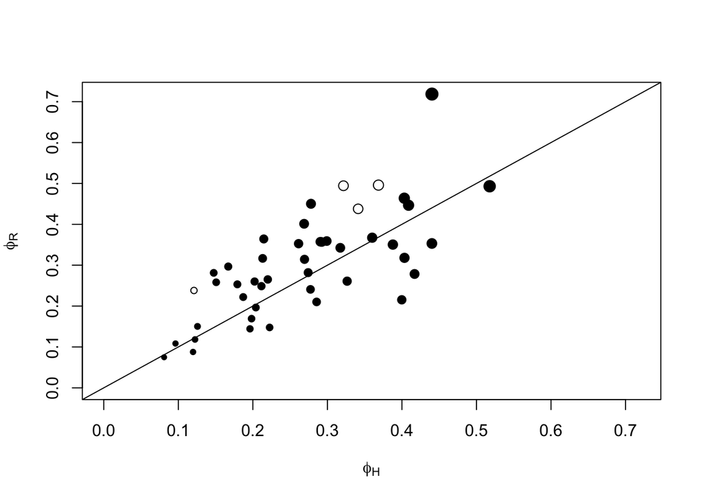

```r
plot(phiR ~ phiH,
    ylim = c(0, max(phiH, phiR)), xlim = c(0, max(phiH, phiR)),
    pch = c(21, 19)[(0 %[]% ci) + 1],
    xlab = expression(phi[H]), ylab = expression(phi[R]),
    cex = 0.5 + 2 * phiHR
)
abline(0, 1)
```

**Exercise**

Which $\phi$ estimate should we use? Can we use `phiHR`? Isn’t that cheating to double the sample size? Think about what we are conditioning on when estimating $\phi$, and what makes samples independent.

# Distance sampling

We estimate EDR from human observer based counts:

```r
#  Data for EDR estimation
xtdis <- Xtab(Count ~ PKEY + DISTANCE + SPECIES,
    data = paired[paired$SurveyType == "HUM", ]
)
xtdis <- xtdis[SPP]
for (i in seq_len(length(xtdis))) {
    xtdis[[i]] <- as.matrix(xtdis[[i]][, c("0-49 m", "50-100 m", ">100 m")])
}
head(xtdis$YRWA)
```

```
            0-49 m 50-100 m >100 m
05-041-01_1      2        3      0
05-041-02_1      1        0      0
05-041-05_1      2        0      1
05-041-06_1      4        2      1
05-041-07_1      0        1      0
05-041-08_1      1        1      0
```

```r
#  distance radii
Ddis <- matrix(c(0.5, 1, Inf), nrow(xtdis[[1]]), 3, byrow = TRUE)
head(Ddis)
```

```
     [,1] [,2] [,3]
[1,]  0.5    1  Inf
[2,]  0.5    1  Inf
[3,]  0.5    1  Inf
[4,]  0.5    1  Inf
[5,]  0.5    1  Inf
[6,]  0.5    1  Inf
```

```r
#  predictors
xdis <- nonDuplicated(paired, PKEY, TRUE)
xdis <- xdis[rownames(xtdis[[1]]), ]
```

Fitting distance sampling models for each species:

```r
mdis <- pblapply(xtdis, function(Y) {
    cmulti(Y | Ddis ~ 1, xdis, type = "dis")
})
```

```r
tauH <- sapply(mdis, function(z) unname(exp(coef(z))))
edrH <- 100 * tauH
round(sort(edrH))
```

```
CEDW CMWA BBWA BLBW BRCR NAWA LEFL AMRE HAWO PHVI MAWA CSWA BCCH OCWA CAWA COYE
  34   36   39   41   42   45   46   51   52   53   54   55   56   59   61   62
TEWA MOWA YRWA PAWA YBSA LISP CCSP DEJU CHSP CONW OVEN REVI CAJA RBGR RCKI RBNU
  63   64   64   65   67   69   70   70   73   74   77   81   82   85   86   88
SWTH AMRO WTSP WIWR ALFL SOSP CAGO BLJA FOSP HETH GRYE WISN PIWO
  91   92   99  101  102  114  129  129  130  138  158  164  167
```

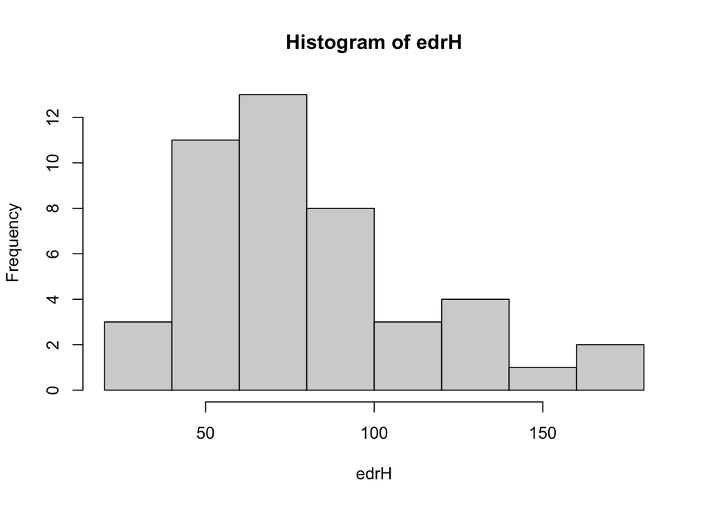

```r
hist(edrH)
```

# Scaling constant

Counts are often modeled in a log-linear Poisson GLM. We used GLM to estimate the unknown scaling constant from simultaneous (paired) surveys. The Poisson mean for a count made at site $i$ by human observer is $\lambda_{i,H} = D_{i} \pi EDR_H^2 p$. $EDR_H$ and $p$ are estimated using distance sampling and removal sampling, respectively. Those estimates are used to calculate a correction factor $C = \pi EDR_H^2 p$ which is used as an offset on the log scale as $log(\lambda_{i,H}) = log(D_{i}) + log(C) = \beta_0 + log(C)$, where $\beta_0$ is the intercept in the GLM model.

Following the arguments above, the Poisson mean for an ARU based count made at site $i$ is $\lambda_{i,R} = D_{i} \pi \Delta^2 EDR_H^2 p = D_{i} \Delta^2 C$. On the log scale, this becomes $log(\lambda_{i,R}) = log(D_{i}) + log(\Delta^2) + log(C) = \beta_0 + \beta_1 + log(C)$, where $\beta_1$ is a contrast for ARU type surveys in the log-linear model.

We used survey type as a binary variable ($x_i$) with value 0 for human observers and value 1 for ARUs. So the Poisson model is generalized as: $log(\lambda_{i}) = \beta_0 + x_i \beta_1 + log(C)$. $\Delta$ can be calculated from $\beta_1$ as $\Delta = \sqrt{e^{\beta_i}}$.

We used the Poisson GLM model describe before to estimate the $\beta_1$ coefficient corresponding to survey type as binary predictor variable, and an offset term incorporating human observer based effective area sampled and availability.

```r
phi <- phiHR
tau <- tauH

Y <- as.matrix(Xtab(Count ~ PKEYm + SPECIES, paired))
X <- nonDuplicated(paired, PKEYm, TRUE)
X <- X[rownames(Y), ]
X$distur <- ifelse(X$Disturbance != "Undisturbed", 1, 0)
X$SurveyType <- factor(X$SurveyType, c("HUM", "ARU"))

library(lme4)
mods <- list()
aictab <- list()
Delta <- matrix(NA, length(SPP), 3)
dimnames(Delta) <- list(SPP, c("est", "lcl", "ucl"))

# spp <- "ALFL"
for (spp in SPP) {
    y <- Y[, spp]
    C <- tau[spp]^2 * pi * (1 - exp(-phi[spp]))
    off <- rep(log(C), nrow(X))

    mod0 <- glm(y ~ 1, X, offset = off, family = poisson)
    mod1 <- glm(y ~ SurveyType, X, offset = off, family = poisson)
    mod2 <- glm(y ~ SurveyType + distur, X, offset = off, family = poisson)

    aic <- AIC(mod0, mod1, mod2)
    aic$delta_AIC <- aic$AIC - min(aic$AIC)
    aictab[[spp]] <- aic

    Best <- get(rownames(aic)[aic$delta_AIC == 0])
    # summary(Best)

    mods[[spp]] <- Best

    #  this is Monte Carlo based CI, no need for Delta method
    bb <- MASS::mvrnorm(10^4, coef(mod1), vcov(mod1))
    Delta[spp, ] <- c(
        sqrt(exp(coef(mod1)["SurveyTypeARU"])),
        quantile(sqrt(exp(bb[, "SurveyTypeARU"])), c(0.025, 0.975))
    )
}

aic_support <- t(sapply(aictab, function(z) z[, 3]))
round(aic_support)
```

```
     [,1] [,2] [,3]
ALFL  247  244    0
AMRE   65   66    0
AMRO   26   21    0
BBWA   22   23    0
BCCH   28   29    0
BLBW   16   18    0
BLJA    5    7    0
BRCR   27   29    0
CAGO   90   25    0
CAJA    0    0    0
CAWA   18   20    0
CCSP   68   68    0
CEDW    9   11    0
CHSP    6    5    0
CMWA   23   25    0
CONW   20   21    0
COYE   14   16    0
CSWA   22   23    0
DEJU  102   99    0
FOSP   97   98    0
GRYE    6    8    0
HAWO    0    1    1
HETH   19   17    0
LEFL    0    2    4
LISP   50   52    0
MAWA    0    1    0
MOWA    0    2    3
NAWA    0    1    1
OCWA  132  133    0
OVEN  378  375    0
PAWA  126  128    0
PHVI    0    2    3
PIWO    8   10    0
RBGR    0    2    1
RBNU   37   38    0
RCKI   13    9    0
REVI   23   21    0
SOSP   65   66    0
SWTH   37   39    0
TEWA   22   15    0
WISN    1    3    0
WIWR   35   35    0
WTSP  167  168    0
YBSA   19   18    0
YRWA   17   14    0
```

The following table show the estimate of $\Delta$ for each species, and the corresponding estimates of effective detection radius (EDR) in meters and effective area sampled ($A$) in ha:

```r
Delta_summary <- data.frame(
    Species = SPP,
    EDR_H = round(edrH),
    EDR_R = round(edrH * Delta[, "est"]),
    A_H = round(tauH^2 * pi, 2),
    A_R = round((Delta[, "est"] * tauH)^2 * pi, 2),
    Delta = round(Delta, 3)
)
Delta_summary
```

```
     Species EDR_H EDR_R  A_H  A_R Delta.est Delta.lcl Delta.ucl
ALFL    ALFL   102    88 3.28 2.43     0.860     0.751     0.986
AMRE    AMRE    51    53 0.81 0.88     1.041     0.897     1.212
AMRO    AMRO    92    74 2.67 1.72     0.803     0.678     0.946
BBWA    BBWA    39    37 0.48 0.42     0.939     0.805     1.100
BCCH    BCCH    56    51 0.99 0.81     0.904     0.736     1.113
BLBW    BLBW    41    39 0.53 0.48     0.951     0.783     1.159
BLJA    BLJA   129   132 5.24 5.45     1.020     0.843     1.235
BRCR    BRCR    42    44 0.56 0.62     1.047     0.884     1.247
CAGO    CAGO   129    83 5.20 2.18     0.647     0.580     0.722
CAJA    CAJA    82    75 2.13 1.76     0.910     0.796     1.045
CAWA    CAWA    61    61 1.17 1.17     1.000     0.771     1.304
CCSP    CCSP    70    55 1.53 0.95     0.788     0.581     1.061
CEDW    CEDW    34    34 0.36 0.36     1.000     0.847     1.185
CHSP    CHSP    73    67 1.68 1.41     0.915     0.834     1.005
CMWA    CMWA    36    39 0.42 0.48     1.074     0.820     1.393
CONW    CONW    74    66 1.73 1.35     0.883     0.703     1.118
COYE    COYE    62    60 1.21 1.12     0.959     0.724     1.266
CSWA    CSWA    55    52 0.95 0.84     0.937     0.810     1.081
DEJU    DEJU    70    59 1.54 1.11     0.849     0.745     0.968
FOSP    FOSP   130   145 5.35 6.56     1.108     0.833     1.459
GRYE    GRYE   158   147 7.83 6.83     0.934     0.739     1.176
HAWO    HAWO    52    44 0.87 0.60     0.832     0.614     1.116
HETH    HETH   138   127 6.02 5.05     0.915     0.836     1.001
LEFL    LEFL    46    44 0.67 0.60     0.949     0.756     1.191
LISP    LISP    69    70 1.49 1.54     1.016     0.795     1.297
MAWA    MAWA    54    51 0.91 0.82     0.948     0.855     1.052
MOWA    MOWA    64    62 1.27 1.22     0.976     0.853     1.119
NAWA    NAWA    45    50 0.65 0.79     1.104     0.897     1.356
OCWA    OCWA    59    53 1.08 0.90     0.913     0.749     1.110
OVEN    OVEN    77    71 1.86 1.60     0.929     0.874     0.989
PAWA    PAWA    65    65 1.34 1.34     1.000     0.825     1.206
PHVI    PHVI    53    53 0.87 0.87     1.000     0.779     1.289
PIWO    PIWO   167   177 8.75 9.87     1.062     0.885     1.271
RBGR    RBGR    85    91 2.29 2.58     1.062     0.857     1.318
RBNU    RBNU    88    82 2.42 2.09     0.929     0.788     1.103
RCKI    RCKI    86    74 2.32 1.74     0.864     0.770     0.973
REVI    REVI    81    75 2.04 1.79     0.935     0.873     1.002
SOSP    SOSP   114   103 4.08 3.35     0.906     0.683     1.189
SWTH    SWTH    91    90 2.59 2.53     0.989     0.901     1.086
TEWA    TEWA    63    56 1.24 0.98     0.890     0.825     0.960
WISN    WISN   164   170 8.44 9.06     1.036     0.836     1.287
WIWR    WIWR   101    93 3.22 2.70     0.917     0.814     1.032
WTSP    WTSP    99    96 3.08 2.92     0.974     0.923     1.028
YBSA    YBSA    67    59 1.43 1.08     0.868     0.733     1.032
YRWA    YRWA    64    57 1.30 1.04     0.892     0.804     0.991
```

But wait, if we started from expected values, shouldn’t ratio of the mean counts give us $\Delta^2$? Let’s see if we can get a similar $\Delta$ value from mean counts:

```r
(gm <- groupMeans(Y[, SPP], 1, X$SurveyType))
```

```
         ALFL      AMRE      AMRO      BBWA       BCCH      BLBW      BLJA
ARU 0.2151589 0.2200489 0.1418093 0.1809291 0.09779951 0.1149144 0.1271394
HUM 0.2909535 0.2029340 0.2200489 0.2053790 0.11980440 0.1271394 0.1222494
         BRCR      CAGO      CAJA       CAWA       CCSP      CEDW      CHSP
ARU 0.1662592 0.2762836 0.2249389 0.06845966 0.04400978 0.1711491 0.4889976
HUM 0.1515892 0.6601467 0.2713936 0.06845966 0.07090465 0.1711491 0.5843521
          CMWA       CONW       COYE      CSWA      DEJU       FOSP       GRYE
ARU 0.07334963 0.07823961 0.05623472 0.2127139 0.2273839 0.06601467 0.08312958
HUM 0.06356968 0.10024450 0.06112469 0.2420538 0.3154034 0.05378973 0.09535452
          HAWO      HETH       LEFL       LISP      MAWA      MOWA      NAWA
ARU 0.04400978 0.5427873 0.08801956 0.07823961 0.4132029 0.2493888 0.1222494
HUM 0.06356968 0.6479218 0.09779951 0.07579462 0.4596577 0.2616137 0.1002445
         OCWA     OVEN      PAWA       PHVI      PIWO       RBGR      RBNU
ARU 0.1100244 1.127139 0.1344743 0.07579462 0.1515892 0.10757946 0.1540342
HUM 0.1320293 1.305623 0.1344743 0.07579462 0.1344743 0.09535452 0.1784841
         RCKI      REVI       SOSP      SWTH      TEWA      WISN      WIWR
ARU 0.2958435 0.9290954 0.05623472 0.5281174 0.7432763 0.1075795 0.3080685
HUM 0.3960880 1.0635697 0.06845966 0.5403423 0.9388753 0.1002445 0.3667482
        WTSP      YBSA      YRWA
ARU 1.559902 0.1418093 0.3814181
HUM 1.643032 0.1882641 0.4792176
```

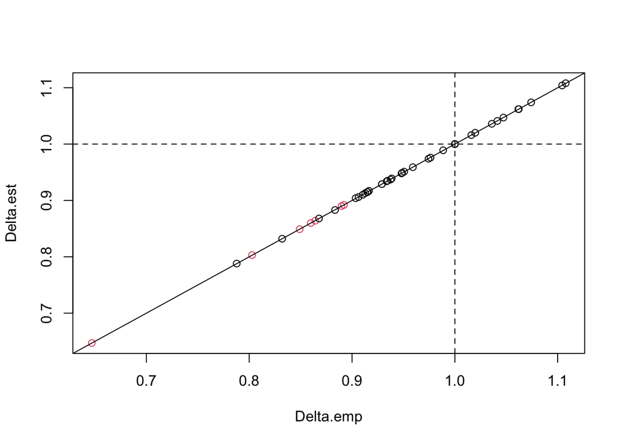

```r
Delta_summary$Delta.emp <- sqrt(gm["ARU", ] / gm["HUM", ])

plot(Delta.est ~ Delta.emp, Delta_summary,
    col = c(2, 1)[(1 %[]% Delta[, -1]) + 1]
)
abline(0, 1)
abline(h = 1, v = 1, lty = 2)
```

It looks like the fancy modeling was all for nothing, theory prevailed. But it is always nice when things work out as expected.

We can also see that $\Delta$ (especially the significant ones) tended to be less than 1, indicating that overall EDR for ARUs is slightly smaller that for human point counts. $\Delta$ was significantly different from 1 only for relatively few species.

**Exercise**

Can we pool all species’ data together to estimate an overall $\Delta$ value? Would that characterize this particular ARU type well enough? What are some of the arguments against this pooling? What might be driving the variation across species?

# Data integration

Now we will pretend that we have no paired design. See how well fixed effects can handle the data integration without calibration.

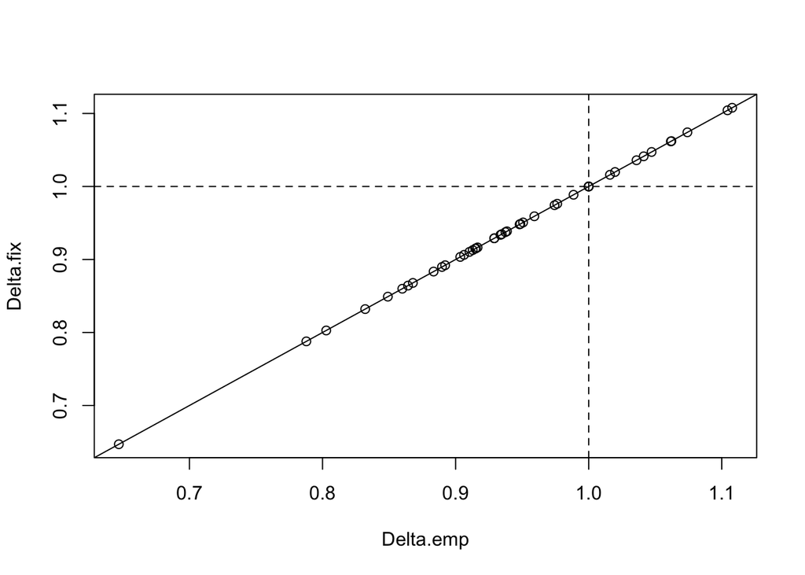

```r
i <- sample(levels(X$PKEY), floor(nlevels(X$PKEY) / 2))
ss <- c(which(X$PKEY %in% i), which(!(X$PKEY %in% i)))

mods2 <- list()
for (spp in SPP) {
    y <- Y[ss, spp]
    C <- tau[spp]^2 * pi * (1 - exp(-phi[spp]))
    off <- rep(log(C), length(ss))

    mod <- glm(y ~ SurveyType, X[ss, ], offset = off, family = poisson)

    mods2[[spp]] <- mod
}
Delta_summary$Delta.fix <- sapply(mods2, function(z) {
    sqrt(exp(coef(z)[2]))
})
plot(Delta.fix ~ Delta.emp, Delta_summary)
abline(0, 1)
abline(h = 1, v = 1, lty = 2)
```

# Exercise

Use the script below to push the fixed effects method to the limit and see where it fails. We will explore the following two situations: (1) sample size and number of detections is small, (2) sampling is biased with respect to habitat strata.

```r
X$open <- ifelse(X$Class_Name %in% c(
    "Open Herb/Grass",
    "Open coniferous", "Open Mature Deciduous", "Open Mixed",
    "Open Northern", "Open Young Deciduous",
    "Open Young Mixed", "Poorly Drained"
), 1, 0)
#  proportion of samples from ARUs (original)
prop_aru <- 0.5
#  proportion of ARU samples coming from open habitats
prop_open <- 0.6

n_aru <- round(nrow(X) * prop_aru)
n_hum <- nrow(X) - n_aru
w_aru <- prop_open * X$open + (1 - prop_open) * (1 - X$open)
w_hum <- (1 - prop_open) * X$open + prop_open * (1 - X$open)

id_aru <- sample(which(X$SurveyType == "ARU"), n_aru,
    replace = TRUE, prob = w_aru[X$SurveyType == "ARU"]
)
id_hum <- sample(which(X$SurveyType == "HUM"), n_hum,
    replace = TRUE, prob = w_hum[X$SurveyType == "HUM"]
)

ss <- c(id_aru, id_hum)
addmargins(with(X[ss, ], table(open, SurveyType)))
```

```
     SurveyType
open  HUM ARU Sum
  0   214 129 343
  1   195 280 475
  Sum 409 409 818
```

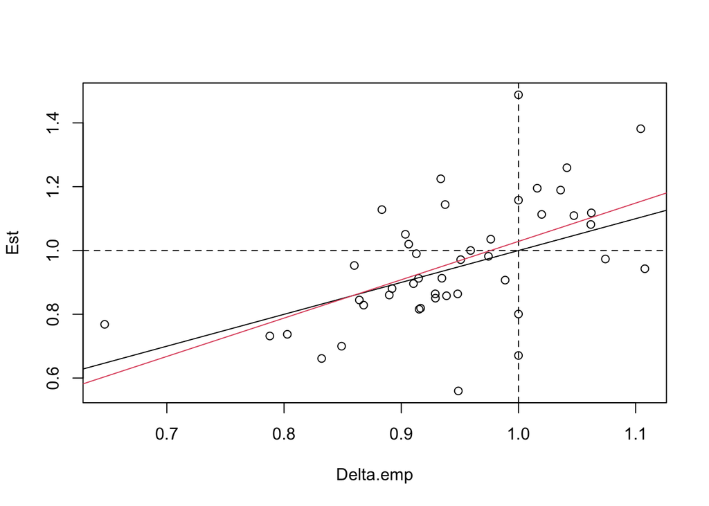

```r
mods3 <- list()
for (spp in SPP) {
    y <- Y[ss, spp]
    C <- tau[spp]^2 * pi * (1 - exp(-phi[spp]))
    off <- rep(log(C), length(ss))

    mod <- glm(y ~ SurveyType, X[ss, ], offset = off, family = poisson)

    mods3[[spp]] <- mod
}


Est <- sapply(mods3, function(z) sqrt(exp(coef(z)[2])))

plot(Est ~ Delta.emp, Delta_summary)
abline(0, 1)
abline(h = 1, v = 1, lty = 2)
abline(lm(Est ~ Delta.emp, Delta_summary), col = 2)
```

`prop_open` 0 vs. 1 leads to different deviation from the 1:1 line, explain why.